# Part 6 Regressions

Master thesis Section 3.5 (main specification) and Chapter 4 (main results)

Author

Lara Mazzarelli

## Role in the pipeline

| **Thesis section** | 3.4 selection check (Table 5), 3.5 main results (H1/H2), 4.1-4.3 results |
| --- | --- |
| **Previous file** | `05_descriptives.qmd` |

## Hypotheses and models (Table 7)

| Hypothesis | Model | Test (supported if) |
| --- | --- | --- |
| **H1** industry distance has an inverted U-shaped effect on revenue growth | `m2` | omnibus equality test of the five distance coefficients (basis), joint test, pairwise contrasts; supported if equality is rejected and D1-D3 exceed both D0 and D4 |
| **H2** the negative effect of large industry distance is weaker for equity-based than for non-equity alliances | `m4` | decline D3 to D4: (D3_EQ - D4_EQ) - (D3_NE - D4_NE); rise D0 to D3: (D3_EQ - D0_EQ) - (D3_NE - D0_NE); supported if both are negative and significant |
| *Additional analysis B1* (no hypothesis): related (D0-D3) vs. unrelated (D4) | `m1` | Wald test of RA - UA; supported if positive and significant |
| *Additional analysis B2* (no hypothesis): related-over-unrelated advantage by governance form | `m3` | (RA_EQ - UA_EQ) - (RA_NE - UA_NE) |

**Main specification:** annualised revenue growth from t to t+3 on `log(1 + alliance counts in t-2 to t)`, four controls (size, ROA, leverage, past growth), firm fixed effects, industry x year and country x year fixed effects, standard errors clustered by firm. Firm age is not included (collinear with firm and year FE).

```r
source("00_config.R")
library(fixest)
library(ggplot2)

d <- readRDS(file.path(path, "analysis_sample.rds"))
d[, sic2 := as.factor(sic2)]

c(firm_years = nrow(d), firms = uniqueN(d$gvkey),
  countries = uniqueN(d$country), country_year_cells = uniqueN(paste(d$country, d$fyear)))
```

```
        firm_years              firms          countries country_year_cells
            461882              43407                124               2880
```

## Helper functions

```r
# Does coefficient a differ from coefficient b? (uses the covariance of the two estimates)
diff_test <- function(m, a, b) {
  v   <- vcov(m)
  est <- coef(m)[[a]] - coef(m)[[b]]
  se  <- sqrt(v[a, a] + v[b, b] - 2 * v[a, b])
  c(est = est, se = se, t = est / se, p = 2 * pnorm(-abs(est / se)))
}

# Any linear combination of coefficients (used for the H2 and A2 difference-in-differences)
lin_test <- function(m, k, cv) {
  b <- coef(m); V <- vcov(m)
  est <- sum(cv * b[k])
  se  <- sqrt(as.numeric(t(cv) %*% V[k, k] %*% cv))
  c(est = est, se = se, t = est / se, p = 2 * pnorm(-abs(est / se)))
}

# Joint significance of the five distance coefficients (H1, fixest Wald test)
joint_p <- function(m, pattern = "^log1p\\(d") {
  wald(m, keep = pattern, print = FALSE)$p
}

# Omnibus test of H1: are the five distance coefficients equal to each other?
# Four restrictions (D0 = D1, D1 = D2, D2 = D3, D3 = D4), chi-square Wald test
omnibus_p <- function(m, pattern = "^log1p\\(d") {
  nm <- grep(pattern, names(coef(m)), value = TRUE)
  stopifnot(length(nm) == 5)
  R <- matrix(0, nrow = 4, ncol = 5)
  for (i in 1:4) { R[i, i] <- 1; R[i, i + 1] <- -1 }
  rb   <- R %*% coef(m)[nm]
  stat <- as.numeric(t(rb) %*% solve(R %*% vcov(m)[nm, nm] %*% t(R)) %*% rb)
  pchisq(stat, df = 4, lower.tail = FALSE)
}

# p-value of A1 (related vs. unrelated) for any model whose first two coefficients are RA and UA
h1_p <- function(m) {
  nm <- names(coef(m))[1:2]
  diff_test(m, nm[1], nm[2])[["p"]]
}

# One-row table from a test result
tidy <- function(label, x) data.table(test = label, est = x[["est"]], se = x[["se"]],
                                      t = x[["t"]], p = x[["p"]])
```

## Specification

All models are built by one function, so that they differ only in the alliance variables (and in the one design choice that is varied in a robustness check).

```r
controls <- "ln_at_usd + roa_w + leverage_w + growth_l1_w"
fe_main  <- "gvkey + sic2^fyear + country^fyear"

est <- function(rhs, fe = fe_main, y = "growth_f3_w", data = d, ctrl = controls) {
  rhs_all <- if (is.null(ctrl)) rhs else paste(rhs, "+", ctrl)
  feols(as.formula(paste0(y, " ~ ", rhs_all, " | ", fe)),
        data = data, cluster = ~gvkey)
}

# Alliance variables of the four models (window suffix: _3y = t-2 to t)
# rhs_h1 = A1 (m1), rhs_h2 = H1 (m2), rhs_h3 = A2 (m3), rhs_h4 = H2 (m4)
rhs_h1 <- "log1p(n_rel_3y) + log1p(n_unrel_3y)"
rhs_dist <- function(suffix) paste0("log1p(", cats, suffix, ")", collapse = " + ")
rhs_h2 <- rhs_dist("_3y")
rhs_h3 <- paste("log1p(n_rel_eq_3y) + log1p(n_rel_ne_3y)",
                "log1p(n_unrel_eq_3y) + log1p(n_unrel_ne_3y)", sep = " + ")
rhs_h4 <- paste0(c(rbind(paste0("log1p(", cats, "_eq_3y)"),
                         paste0("log1p(", cats, "_ne_3y)"))), collapse = " + ")

# Readable labels for the tables
dict <- c(growth_f3_w                  = "Revenue growth t to t+3",
          growth_f1_w                  = "Revenue growth t to t+1",
          "log1p(n_rel_3y)"            = "Related alliances (D0-D3)",
          "log1p(n_unrel_3y)"          = "Unrelated alliances (D4)",
          "log1p(d0_same4_3y)"         = "D0 same 4-digit",
          "log1p(d1_same3_3y)"         = "D1 same 3-digit",
          "log1p(d2_same2_3y)"         = "D2 same 2-digit",
          "log1p(d3_same_division_3y)" = "D3 same division",
          "log1p(d4_diff_division_3y)" = "D4 different division",
          "log1p(d0_same4)"            = "D0 same 4-digit (year t)",
          "log1p(d1_same3)"            = "D1 same 3-digit (year t)",
          "log1p(d2_same2)"            = "D2 same 2-digit (year t)",
          "log1p(d3_same_division)"    = "D3 same division (year t)",
          "log1p(d4_diff_division)"    = "D4 different division (year t)",
          "log1p(n_rel_eq_3y)"         = "Related, equity-based",
          "log1p(n_rel_ne_3y)"         = "Related, non-equity",
          "log1p(n_unrel_eq_3y)"       = "Unrelated, equity-based",
          "log1p(n_unrel_ne_3y)"       = "Unrelated, non-equity",
          ln_at_usd                    = "Size (ln assets, USD)",
          roa_w                        = "ROA",
          leverage_w                   = "Leverage",
          growth_l1_w                  = "Past growth",
          gvkey                        = "Firm",
          "sic2^fyear"                 = "Industry x Year",
          "country^fyear"              = "Country x Year")
```

## 1. H1: inverted U-shaped effect of industry distance

**H1:** industry distance has an inverted U-shaped effect on a focal firm’s subsequent revenue growth.

One coefficient per category imposes no shape, so the data can show any pattern (a squared distance term would force a symmetric parabola). An inverted U requires the middle categories D1-D3 to exceed both extremes D0 and D4.

```r
m2 <- est(rhs_h2)
tab_m2 <- etable(m2, dict = dict, digits = 4, fitstat = ~ n + r2 + wr2, tex = FALSE)
knitr::kable(tab_m2)
```

|  | m2 |
| --- | --- |
| Dependent Var.: | Revenue growth t to t+3 |
| D0 same 4-digit | -0.0064* (0.0033) |
| D1 same 3-digit | -0.0040 (0.0034) |
| D2 same 2-digit | -0.0012 (0.0030) |
| D3 same division | 0.0014 (0.0024) |
| D4 different division | -0.0042* (0.0018) |
| Size (ln assets, USD) | -0.0886*** (0.0012) |
| ROA | -0.0072 (0.0051) |
| Leverage | -0.1024*** (0.0039) |
| Past growth | -0.0089*** (0.0012) |
| Fixed-Effects: | ———————– |
| Firm | Yes |
| Industry x Year | Yes |
| Country x Year | Yes |
| _____________________ | _______________________ |
| S.E.: Clustered | by: Firm |
| Observations | 457,325 |
| R2 | 0.44288 |
| Within R2 | 0.08182 |

```r
nm2 <- function(k, suffix = "_3y") paste0("log1p(", k, suffix, ")")

# (a) joint test, (b) omnibus test (basis for H1), (c) pairwise contrasts
h1_global <- data.table(test = c("Joint significance of D0-D4", "Omnibus: all five equal"),
                        p = c(joint_p(m2), omnibus_p(m2)))
knitr::kable(h1_global, digits = 4)
```

| test | p |
| --- | --- |
| Joint significance of D0-D4 | 0.0231 |
| Omnibus: all five equal | 0.2578 |

```r
pr <- CJ(mid = cats[2:4], ext = cats[c(1, 5)], sorted = FALSE)
pairwise <- rbindlist(lapply(seq_len(nrow(pr)), function(i) {
  tidy(paste(pr$mid[i], "-", pr$ext[i]), diff_test(m2, nm2(pr$mid[i]), nm2(pr$ext[i])))
}))
knitr::kable(pairwise, digits = 4, caption = "Pairwise contrasts: middle category minus extreme")
```

Pairwise contrasts: middle category minus extreme

| test | est | se | t | p |
| --- | --- | --- | --- | --- |
| d1_same3 - d0_same4 | 0.0024 | 0.0049 | 0.4923 | 0.6225 |
| d1_same3 - d4_diff_division | 0.0002 | 0.0040 | 0.0544 | 0.9566 |
| d2_same2 - d0_same4 | 0.0053 | 0.0045 | 1.1613 | 0.2455 |
| d2_same2 - d4_diff_division | 0.0031 | 0.0038 | 0.8026 | 0.4222 |
| d3_same_division - d0_same4 | 0.0078 | 0.0040 | 1.9322 | 0.0533 |
| d3_same_division - d4_diff_division | 0.0056 | 0.0031 | 1.7834 | 0.0745 |

### How the three tests fit together

The joint test only asks whether distance matters at all; it can be significant because both extremes are negative, without any systematic variation with distance. The omnibus test asks whether the five coefficients differ from each other, which is the actual shape test. The pairwise contrasts are supporting evidence only: with six comparisons, one or two below 5% are expected by chance.

## 2. H2: governance form moderates the effect of large distance

**H2:** the negative effect of large industry distance on revenue growth is weaker for equity-based than for non-equity alliances.

An alliance is equity-based if the SDC Joint Venture Flag is true (a new jointly owned entity was created) or if the Alliance Technique contains Equity Transfer or Cross Equity Transfer (see file 1, section 1b); all other alliances are non-equity (`equity_definition` in `00_config.R`). The governance form is defined at alliance level but the regression is at firm-year level, so the category counts are split by governance form instead of using an interaction term. This also works when a firm forms both types in the same year. Model `m4` therefore has ten alliance coefficients (five distance categories x two governance forms). The penalty of large distance is the decline from the moderate category D3 to D4; H2 holds if this decline is smaller for equity-based alliances.

D3 is the moderate category (the intermediate category with the highest coefficient in the main distance model `m2` of H1).

```r
m4 <- est(rhs_h4)
tab_m4 <- etable(m4, dict = dict, digits = 4, fitstat = ~ n + r2 + wr2, tex = FALSE)
knitr::kable(tab_m4)
```

|  | m4 |
| --- | --- |
| Dependent Var.: | Revenue growth t to t+3 |
| log1p(d0_same4_eq_3y) | -0.0027 (0.0050) |
| log1p(d0_same4_ne_3y) | -0.0070. (0.0037) |
| log1p(d1_same3_eq_3y) | -0.0064 (0.0059) |
| log1p(d1_same3_ne_3y) | -0.0023 (0.0038) |
| log1p(d2_same2_eq_3y) | -0.0014 (0.0043) |
| log1p(d2_same2_ne_3y) | -0.0005 (0.0038) |
| log1p(d3_same_division_eq_3y) | 0.0029 (0.0038) |
| log1p(d3_same_division_ne_3y) | 0.0014 (0.0028) |
| log1p(d4_diff_division_eq_3y) | -0.0014 (0.0029) |
| log1p(d4_diff_division_ne_3y) | -0.0051* (0.0021) |
| Size (ln assets, USD) | -0.0886*** (0.0012) |
| ROA | -0.0072 (0.0051) |
| Leverage | -0.1024*** (0.0039) |
| Past growth | -0.0089*** (0.0012) |
| Fixed-Effects: | ———————– |
| Firm | Yes |
| Industry x Year | Yes |
| Country x Year | Yes |
| _____________________________ | _______________________ |
| S.E.: Clustered | by: Firm |
| Observations | 457,325 |
| R2 | 0.44288 |
| Within R2 | 0.08183 |

```r
# which intermediate category is highest in the main model?
coef(m2)[nm2(cats[2:4])]
```

```
        log1p(d1_same3_3y)         log1p(d2_same2_3y)
              -0.004013108               -0.001173552
log1p(d3_same_division_3y)
               0.001386585
```

```r
k_h4 <- c("log1p(d3_same_division_eq_3y)", "log1p(d4_diff_division_eq_3y)",
          "log1p(d3_same_division_ne_3y)", "log1p(d4_diff_division_ne_3y)")
h2_tests <- rbind(
  tidy("Decline D3 to D4, equity-based", diff_test(m4, k_h4[1], k_h4[2])),
  tidy("Decline D3 to D4, non-equity",    diff_test(m4, k_h4[3], k_h4[4])),
  tidy("H2: (D3_EQ - D4_EQ) - (D3_NE - D4_NE)", lin_test(m4, k_h4, c(1, -1, -1, 1))))
knitr::kable(h2_tests, digits = 4)
```

| test | est | se | t | p |
| --- | --- | --- | --- | --- |
| Decline D3 to D4, equity-based | 0.0043 | 0.0050 | 0.8675 | 0.3857 |
| Decline D3 to D4, non-equity | 0.0065 | 0.0036 | 1.7882 | 0.0737 |
| H2: (D3_EQ - D4_EQ) - (D3_NE - D4_NE) | -0.0022 | 0.0063 | -0.3445 | 0.7305 |

```r
# H2, close end: the rise from D0 to D3 should be smaller for equity-based alliances
k_h4_close <- c("log1p(d3_same_division_eq_3y)", "log1p(d0_same4_eq_3y)",
                "log1p(d3_same_division_ne_3y)", "log1p(d0_same4_ne_3y)")
h2_close <- rbind(
  tidy("Rise D0 to D3, equity-based", diff_test(m4, k_h4_close[1], k_h4_close[2])),
  tidy("Rise D0 to D3, non-equity",   diff_test(m4, k_h4_close[3], k_h4_close[4])),
  tidy("H2 close end: (D3_EQ - D0_EQ) - (D3_NE - D0_NE)",
       lin_test(m4, k_h4_close, c(1, -1, -1, 1))))
knitr::kable(h2_close, digits = 4)
```

| test | est | se | t | p |
| --- | --- | --- | --- | --- |
| Rise D0 to D3, equity-based | 0.0056 | 0.0061 | 0.9110 | 0.3623 |
| Rise D0 to D3, non-equity | 0.0084 | 0.0046 | 1.8111 | 0.0701 |
| H2 close end: (D3_EQ - D0_EQ) - (D3_NE - D0_NE) | -0.0028 | 0.0077 | -0.3630 | 0.7166 |

## 3. Additional analyses

### 3.1 B1: related (D0-D3) vs. unrelated (D4)

Previous research mostly distinguishes related from unrelated alliances. This analysis keeps that comparison next to the five-category model of H1 (no hypothesis).

```r
m1 <- est(rhs_h1)
tab_m1 <- etable(m1, dict = dict, digits = 4, fitstat = ~ n + r2 + wr2, tex = FALSE)
knitr::kable(tab_m1)
```

|  | m1 |
| --- | --- |
| Dependent Var.: | Revenue growth t to t+3 |
| Related alliances (D0-D3) | -0.0033. (0.0017) |
| Unrelated alliances (D4) | -0.0042* (0.0019) |
| Size (ln assets, USD) | -0.0886*** (0.0012) |
| ROA | -0.0072 (0.0051) |
| Leverage | -0.1024*** (0.0039) |
| Past growth | -0.0089*** (0.0012) |
| Fixed-Effects: | ———————– |
| Firm | Yes |
| Industry x Year | Yes |
| Country x Year | Yes |
| _________________________ | _______________________ |
| S.E.: Clustered | by: Firm |
| Observations | 457,325 |
| R2 | 0.44287 |
| Within R2 | 0.08181 |

```r
# feols drops singleton observations (firms seen in only one year); they have
# no within-firm variation. Number of observations actually used:
c(sample = nrow(d), used = nobs(m1))
```

```
sample   used
461882 457325
```

```r
knitr::kable(tidy("A1: related - unrelated", diff_test(m1, "log1p(n_rel_3y)", "log1p(n_unrel_3y)")),
             digits = 4)
```

| test | est | se | t | p |
| --- | --- | --- | --- | --- |
| A1: related - unrelated | 9e-04 | 0.0027 | 0.3203 | 0.7488 |

### 3.2 B2: related-over-unrelated advantage by governance form

Same logic as H2 (counts split by governance form, equity definition as in section 2), but with the two relatedness groups instead of the five categories. No hypothesis.

```r
m3 <- est(rhs_h3)
tab_m3 <- etable(m3, dict = dict, digits = 4, fitstat = ~ n + r2 + wr2, tex = FALSE)
knitr::kable(tab_m3)
```

|  | m3 |
| --- | --- |
| Dependent Var.: | Revenue growth t to t+3 |
| Related, equity-based | -0.0017 (0.0026) |
| Related, non-equity | -0.0031 (0.0020) |
| Unrelated, equity-based | -0.0012 (0.0029) |
| Unrelated, non-equity | -0.0050* (0.0021) |
| Size (ln assets, USD) | -0.0886*** (0.0012) |
| ROA | -0.0072 (0.0051) |
| Leverage | -0.1024*** (0.0039) |
| Past growth | -0.0089*** (0.0012) |
| Fixed-Effects: | ———————– |
| Firm | Yes |
| Industry x Year | Yes |
| Country x Year | Yes |
| _______________________ | _______________________ |
| S.E.: Clustered | by: Firm |
| Observations | 457,325 |
| R2 | 0.44287 |
| Within R2 | 0.08181 |

```r
k_h3 <- c("log1p(n_rel_eq_3y)", "log1p(n_unrel_eq_3y)",
          "log1p(n_rel_ne_3y)", "log1p(n_unrel_ne_3y)")

h3 <- rbind(
  tidy("Relatedness advantage, equity-based (RA_EQ - UA_EQ)",
       diff_test(m3, "log1p(n_rel_eq_3y)", "log1p(n_unrel_eq_3y)")),
  tidy("Relatedness advantage, non-equity (RA_NE - UA_NE)",
       diff_test(m3, "log1p(n_rel_ne_3y)", "log1p(n_unrel_ne_3y)")),
  tidy("A2: (RA_EQ - UA_EQ) - (RA_NE - UA_NE)", lin_test(m3, k_h3, c(1, -1, -1, 1))))
knitr::kable(h3, digits = 4)
```

| test | est | se | t | p |
| --- | --- | --- | --- | --- |
| Relatedness advantage, equity-based (RA_EQ - UA_EQ) | -0.0005 | 0.0042 | -0.1233 | 0.9019 |
| Relatedness advantage, non-equity (RA_NE - UA_NE) | 0.0019 | 0.0031 | 0.6019 | 0.5472 |
| A2: (RA_EQ - UA_EQ) - (RA_NE - UA_NE) | -0.0024 | 0.0053 | -0.4558 | 0.6485 |

```r
# Firms with both alliance types over time
firms_both <- d[, .(any_eq = any(n_jv_3y > 0), any_ne = any(n_ca_3y > 0)), by = gvkey]
firms_both[, .(firms = .N,
               with_equity = sum(any_eq), with_non_equity = sum(any_ne),
               both_types = sum(any_eq & any_ne))]
```

```
   firms with_equity with_non_equity both_types
   <int>       <int>           <int>      <int>
1: 43407        4464            7627       2502
```

### 3.3 Exploratory: equity main effect (not pre-specified)

```r
eq_main <- rbind(
  tidy("Equity main effect (avg. equity-based - avg. non-equity)", lin_test(m3, k_h3, c(0.5, 0.5, -0.5, -0.5))),
  tidy("Within related: equity-based - non-equity",   diff_test(m3, "log1p(n_rel_eq_3y)",   "log1p(n_rel_ne_3y)")),
  tidy("Within unrelated: equity-based - non-equity", diff_test(m3, "log1p(n_unrel_eq_3y)", "log1p(n_unrel_ne_3y)")))
knitr::kable(eq_main, digits = 4)
```

| test | est | se | t | p |
| --- | --- | --- | --- | --- |
| Equity main effect (avg. equity-based - avg. non-equity) | 0.0026 | 0.0023 | 1.1274 | 0.2596 |
| Within related: equity-based - non-equity | 0.0013 | 0.0033 | 0.4072 | 0.6839 |
| Within unrelated: equity-based - non-equity | 0.0038 | 0.0036 | 1.0341 | 0.3011 |

## 4. Regression tables

```r
ord <- c("D0", "D1", "D2", "D3", "D4", "Related", "Unrelated")

# Refit without country x year FE (R1), only for the comparison column below;
# the full R1 check and the other robustness checks are in 07_robustness_checks.qmd
m1_r1 <- est(rhs_h1, fe = "gvkey + sic2^fyear")
m2_r1 <- est(rhs_h2, fe = "gvkey + sic2^fyear")

tab_main <- etable(m2_r1, m2, m4, m1_r1, m1, m3, dict = dict,
                   headers = c("H1 (R1)", "H1", "H2", "B1 (R1)", "B1", "B2"),
                   digits = 4, fitstat = ~ n + r2 + wr2, order = ord)
knitr::kable(tab_main)
```

|  | m2_r1 | m2 | m4 | m1_r1 | m1 | m3 |
| --- | --- | --- | --- | --- | --- | --- |
|  | H1 (R1) | H1 | H2 | B1 (R1) | B1 | B2 |
| Dependent Var.: | Revenue growth t to t+3 | Revenue growth t to t+3 | Revenue growth t to t+3 | Revenue growth t to t+3 | Revenue growth t to t+3 | Revenue growth t to t+3 |
| Related alliances (D0-D3) |  |  |  | -0.0025 (0.0017) | -0.0033. (0.0017) |  |
| D0 same 4-digit | -0.0069* (0.0033) | -0.0064* (0.0033) |  |  |  |  |
| D1 same 3-digit | -0.0024 (0.0034) | -0.0040 (0.0034) |  |  |  |  |
| D2 same 2-digit | -0.0005 (0.0030) | -0.0012 (0.0030) |  |  |  |  |
| D3 same division | 0.0020 (0.0025) | 0.0014 (0.0024) |  |  |  |  |
| Unrelated alliances (D4) |  |  |  | -0.0025 (0.0019) | -0.0042* (0.0019) |  |
| D4 different division | -0.0026 (0.0019) | -0.0042* (0.0018) |  |  |  |  |
| Related, equity-based |  |  |  |  |  | -0.0017 (0.0026) |
| Related, non-equity |  |  |  |  |  | -0.0031 (0.0020) |
| Unrelated, equity-based |  |  |  |  |  | -0.0012 (0.0029) |
| Unrelated, non-equity |  |  |  |  |  | -0.0050* (0.0021) |
| Size (ln assets, USD) | -0.0872*** (0.0011) | -0.0886*** (0.0012) | -0.0886*** (0.0012) | -0.0871*** (0.0011) | -0.0886*** (0.0012) | -0.0886*** (0.0012) |
| ROA | 0.0043 (0.0052) | -0.0072 (0.0051) | -0.0072 (0.0051) | 0.0042 (0.0052) | -0.0072 (0.0051) | -0.0072 (0.0051) |
| Leverage | -0.0972*** (0.0039) | -0.1024*** (0.0039) | -0.1024*** (0.0039) | -0.0972*** (0.0039) | -0.1024*** (0.0039) | -0.1024*** (0.0039) |
| Past growth | -0.0073*** (0.0012) | -0.0089*** (0.0012) | -0.0089*** (0.0012) | -0.0073*** (0.0012) | -0.0089*** (0.0012) | -0.0089*** (0.0012) |
| log1p(d0_same4_eq_3y) |  |  | -0.0027 (0.0050) |  |  |  |
| log1p(d0_same4_ne_3y) |  |  | -0.0070. (0.0037) |  |  |  |
| log1p(d1_same3_eq_3y) |  |  | -0.0064 (0.0059) |  |  |  |
| log1p(d1_same3_ne_3y) |  |  | -0.0023 (0.0038) |  |  |  |
| log1p(d2_same2_eq_3y) |  |  | -0.0014 (0.0043) |  |  |  |
| log1p(d2_same2_ne_3y) |  |  | -0.0005 (0.0038) |  |  |  |
| log1p(d3_same_division_eq_3y) |  |  | 0.0029 (0.0038) |  |  |  |
| log1p(d3_same_division_ne_3y) |  |  | 0.0014 (0.0028) |  |  |  |
| log1p(d4_diff_division_eq_3y) |  |  | -0.0014 (0.0029) |  |  |  |
| log1p(d4_diff_division_ne_3y) |  |  | -0.0051* (0.0021) |  |  |  |
| Fixed-Effects: | ———————– | ———————– | ———————– | ———————– | ———————– | ———————– |
| Firm | Yes | Yes | Yes | Yes | Yes | Yes |
| Industry x Year | Yes | Yes | Yes | Yes | Yes | Yes |
| Country x Year | No | Yes | Yes | No | Yes | Yes |
| _____________________________ | _______________________ | _______________________ | _______________________ | _______________________ | _______________________ | _______________________ |
| S.E.: Clustered | by: Firm | by: Firm | by: Firm | by: Firm | by: Firm | by: Firm |
| Observations | 457,803 | 457,325 | 457,325 | 457,803 | 457,325 | 457,325 |
| R2 | 0.41289 | 0.44288 | 0.44288 | 0.41287 | 0.44287 | 0.44287 |
| Within R2 | 0.08667 | 0.08182 | 0.08183 | 0.08665 | 0.08181 | 0.08181 |

```r
fwrite(as.data.table(tab_main), file.path(path, "table_main_results.csv"))
```

The relevant R² is the **within** R² (`wr2`), the share of variation explained after the fixed effects are taken out; `summary()` reports the adjusted R², `etable()` the plain R².

## 5. Figures

### Distance effect (H1)

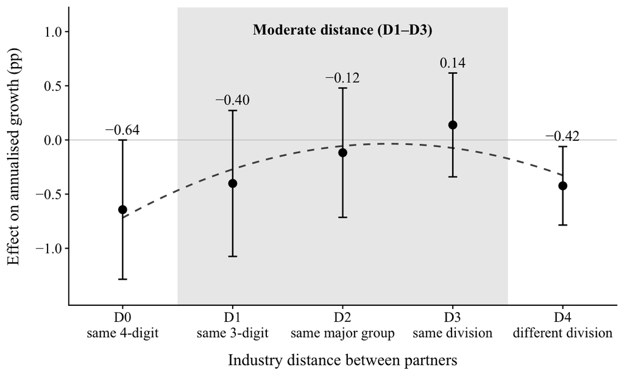

Figure 1

```r
fam <- "Times New Roman"
show_band <- TRUE   # TRUE = grey area for the moderate categories, FALSE = no area

co <- as.data.table(coeftable(m2), keep.rownames = "term")[grepl("^log1p\\(d", term)]
setnames(co, c("Estimate", "Std. Error"), c("est", "se"))
co[, `:=`(est = 100 * est, se = 100 * se)]            # percentage points
lab <- c("D0\nsame 4-digit", "D1\nsame 3-digit", "D2\nsame major group",
         "D3\nsame division", "D4\ndifferent division")
co[, `:=`(x = 1:5, lo = est - 1.96 * se, hi = est + 1.96 * se)]
co[, txt := sub("-", "\u2212", sprintf("%.2f", est))]  # proper minus sign

# smooth inverted-U curve: quadratic fit to the five estimates (illustration only)
fit   <- lm(est ~ x + I(x^2), data = co)
curve <- data.table(x = seq(1, 5, length.out = 100))
curve[, y := predict(fit, newdata = curve)]

p_coef <- ggplot(co, aes(x = x, y = est)) +
  { if (show_band) annotate("rect", xmin = 1.5, xmax = 4.5, ymin = -Inf, ymax = Inf, fill = "grey92") } +
  { if (show_band) annotate("text", x = 3, y = 1.02, label = "Moderate distance (D1\u2013D3)",
                            family = fam, fontface = "bold", size = 3.9, colour = "black") } +
  geom_hline(yintercept = 0, colour = "grey80", linewidth = 0.3) +
  geom_line(data = curve, aes(x = x, y = y), colour = "grey30",
            linetype = "dashed", linewidth = 0.6) +
  geom_errorbar(aes(ymin = lo, ymax = hi), width = 0.08, linewidth = 0.5, colour = "black") +
  geom_point(size = 2.4, colour = "black") +
  geom_text(aes(y = hi, label = txt), vjust = -0.6, family = fam, size = 3.8) +
  scale_x_continuous(breaks = 1:5, labels = lab, expand = expansion(add = 0.45)) +
  scale_y_continuous(breaks = seq(-1, 1, 0.5),
                     labels = function(x) sub("-", "\u2212", format(x, nsmall = 1))) +
  coord_cartesian(ylim = c(-1.4, 1.1)) +
  labs(x = "Industry distance between partners",
       y = "Effect on annualised growth (pp)") +
  theme_classic(base_size = 11, base_family = fam) +
  theme(axis.text    = element_text(colour = "black", size = 10.5),
        axis.title   = element_text(colour = "black", size = 12),
        axis.title.x = element_text(margin = margin(t = 10)),
        axis.title.y = element_text(margin = margin(r = 10)),
        axis.line    = element_line(colour = "black", linewidth = 0.4),
        axis.ticks   = element_line(colour = "black", linewidth = 0.4))
p_coef
ggsave(file.path(path, "fig_coefficients_h1.png"), p_coef,
       width = 6.3, height = 3.8, dpi = 300)
```

### Governance form (H2)

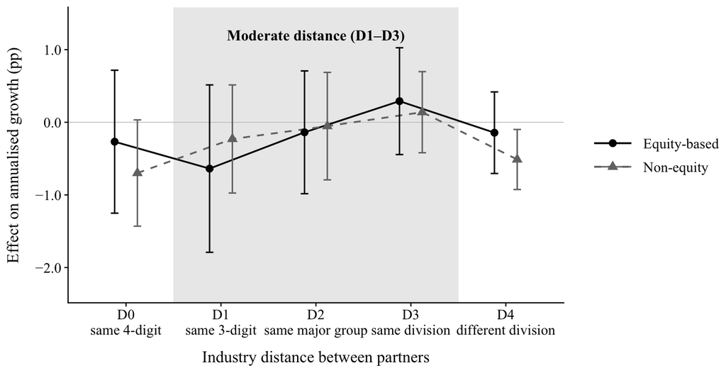

Figure 2

```r
fam   <- "Times New Roman"
dodge <- 0.12   # small horizontal offset so the two series do not overlap

cf <- as.data.table(coeftable(m4), keep.rownames = "term")[
  grepl("^log1p\\(d[0-4]_.*_(eq|ne)_3y\\)$", term)]
setnames(cf, c("Estimate", "Std. Error"), c("est", "se"))
cf[, `:=`(est = 100 * est, se = 100 * se)]                       # percentage points
cf[, gov := factor(ifelse(grepl("_eq_3y", term), "Equity-based", "Non-equity"),
                   levels = c("Equity-based", "Non-equity"))]
cf[, x  := as.integer(sub("^log1p\\(d([0-4]).*$", "\\1", term)) + 1L]
cf[, xp := x + ifelse(gov == "Equity-based", -dodge, dodge)]
cf[, `:=`(lo = est - 1.96 * se, hi = est + 1.96 * se)]
stopifnot(nrow(cf) == 10)

lab2 <- c("D0\nsame 4-digit", "D1\nsame 3-digit", "D2\nsame major group",
          "D3\nsame division", "D4\ndifferent division")

p_h2 <- ggplot(cf, aes(x = xp, y = est, group = gov)) +
  annotate("rect", xmin = 1.5, xmax = 4.5, ymin = -Inf, ymax = Inf, fill = "grey92") +
  annotate("text", x = 3, y = 1.2, label = "Moderate distance (D1\u2013D3)",
           family = fam, fontface = "bold", size = 3.9, colour = "black") +
  geom_hline(yintercept = 0, colour = "grey80", linewidth = 0.3) +
  geom_line(aes(colour = gov, linetype = gov), linewidth = 0.6) +
  geom_errorbar(aes(ymin = lo, ymax = hi, colour = gov), width = 0.08, linewidth = 0.5) +
  geom_point(aes(colour = gov, shape = gov), size = 2.4) +
  scale_colour_manual(NULL, values = c("black", "grey45")) +
  scale_shape_manual(NULL,  values = c(16, 17)) +
  scale_linetype_manual(NULL, values = c("solid", "dashed")) +
  scale_x_continuous(breaks = 1:5, labels = lab2, expand = expansion(add = 0.45)) +
  scale_y_continuous(breaks = seq(-2, 1, 1),
                     labels = function(x) sub("-", "\u2212", format(x, nsmall = 1))) +
  coord_cartesian(ylim = c(-2.3, 1.4)) +
  labs(x = "Industry distance between partners",
       y = "Effect on annualised growth (pp)") +
  theme_classic(base_size = 11, base_family = fam) +
  theme(axis.text    = element_text(colour = "black", size = 10.5),
        axis.title   = element_text(colour = "black", size = 12),
        axis.title.x = element_text(margin = margin(t = 10)),
        axis.title.y = element_text(margin = margin(r = 10)),
        axis.line    = element_line(colour = "black", linewidth = 0.4),
        axis.ticks   = element_line(colour = "black", linewidth = 0.4),
        legend.position      = "right",
        legend.direction     = "vertical",
        legend.justification = "center",
        legend.text          = element_text(size = 10.5),
        legend.key.width     = grid::unit(1.2, "cm"),
        legend.margin        = margin(l = 8))
p_h2
ggsave(file.path(path, "fig_coefficients_h2.png"), p_h2,
       width = 7.4, height = 3.8, dpi = 300)
```

```r
# Table 5 in the thesis: growth history and size by closest alliance distance.
# Computed here rather than in 05_descriptives.qmd because it needs the
# regression-ready sample d built in this file.
# Do firm-years with close partners already differ in growth history and size?
cnt <- paste0(cats, "_3y")
dd  <- copy(d)
dd[, closest := NA_character_]
for (k in rev(seq_along(cats))) dd[get(cnt[k]) > 0, closest := cats[k]]   # the closest category is written last
dd[is.na(closest), closest := "no alliance"]
dd[, closest := factor(closest, levels = c("no alliance", cats))]
sel <- dd[, .(firm_years          = .N,
              past_growth_median  = median(growth_l1_w, na.rm = TRUE),
              past_growth_mean    = mean(growth_l1_w,   na.rm = TRUE),
              size_median         = median(ln_at_usd,   na.rm = TRUE),
              leverage_median     = median(leverage_w,  na.rm = TRUE),
              roa_median          = median(roa_w,       na.rm = TRUE)),
          by = closest][order(closest)]
knitr::kable(sel, digits = 3, caption = "Table 5: Growth history and size by closest alliance distance")
```

Table 5: Growth history and size by closest alliance distance

| closest | firm_years | past_growth_median | past_growth_mean | size_median | leverage_median | roa_median |
| --- | --- | --- | --- | --- | --- | --- |
| no alliance | 414112 | 0.068 | 0.140 | 5.290 | 0.494 | 0.034 |
| d0_same4 | 9790 | 0.091 | 0.201 | 7.505 | 0.513 | 0.038 |
| d1_same3 | 7042 | 0.102 | 0.219 | 6.712 | 0.485 | 0.035 |
| d2_same2 | 5544 | 0.065 | 0.132 | 7.520 | 0.557 | 0.037 |
| d3_same_division | 8903 | 0.070 | 0.137 | 6.933 | 0.543 | 0.036 |
| d4_diff_division | 16491 | 0.074 | 0.150 | 6.738 | 0.544 | 0.033 |